# 3월 30일 숙제

2018.3.30

# 1 library 불러오기

에러가 나면 tools - package install 하세요.

```r
library(ggplot2)
library(scales)
library(Hmisc)
library(data.table)
library(readr)
```

# 2 자료 불러오기

빗자루로 메모리 청소. 앞에서 RData 형식으로 저장한 파일을 불러온다.

```r
load(file="C:/Users/Home/Desktop/dt8.RData")
dt8 = data.table(dt8)
```

dt8 자료의 변수가 의미하는 바는 다음과 같다.

V1 가구번호  
V2 조사년도  
V3 조사부문  
V4 가구주성별  
V5 가구주만나이  
V6 가구주동거여부  
V7 가구주교육정도_학교  
V8 가구주교육정도_수료여부  
V9 가구주혼인상태  
V10 가구주종사상지위  
V11 가구주산업  
V12 가구주직업  
V13 가구원수  
V14 가구유형  
V15 현재살고있는주택의종류  
V16 전용면적  
V17 현재살고있는주택의입주형태  
V18 자산총액  
V19 금융자산  
V20 저축액  
V21 적립식저축  
V22 예치식저축  
V23 기타저축  
V24 현거주지전월세보증금  
V25 실물자산  
V26 부동산  
V27 거주주택  
V28 거주주택이외부동산  
V29 계약금및중도금납입액  
V30 기타실물자산  
V31 자동차  
V32 자동차이외  
V33 부채총액  
V34 금융부채  
V35 담보대출  
V36 부동산담보대출  
V37 거주주택담보대출  
V38 신용대출  
V39 신용카드관련대출  
V40 외상및할부미상환액  
V41 곗탄후불입금액  
V42 임대보증금  
V43 순자산액  
V44 경상소득  
V45 근로소득  
V46 사업소득  
V47 재산소득  
V48 이전소득  
V49 공적이전소득  
V50 사적이전소득  
V51 가처분소득  
V52 균등화가처분소득_분배  
V53 비소비지출  
V54 세금및과징금  
V55 공적연금및사회보험료  
V56 가구간이전  
V57 비영리단체이전  
V58 연간지급이자  
V59 연간상환액  
V60 연간지급이자및상환액  
V61 담보대출용도별(담보_대출잔액)  
V62 거주주택마련(담보_대출잔액)  
V63 거주주택이외부동산마련(담보_대출잔액)  
V64 전(월)세보증금마련(담보_대출잔액)  
V65 증권투자금마련(담보_대출잔액)  
V66 부채상환(담보_대출잔액)  
V67 사업자금(영농자금포함)마련(담보_대출잔액)  
V68 결혼자금마련(담보_대출잔액)  
V69 의료비마련(담보_대출잔액)  
V70 교육비마련(담보_대출잔액)  
V71 생활비마련(담보_대출잔액)  
V72 기타용도(담보_대출잔액)  
V73 담보형태(담보_대출잔액)  
V74 거주주택담보(담보_대출잔액)  
V75 거주주택이외부동산담보(담보_대출잔액)  
V76 예금,적금,보험담보(담보_대출잔액)  
V77 기타담보형태(담보_대출잔액)  
V78 신용대출용도(신용_대출잔액)  
V79 거주주택마련(신용_대출잔액)  
V80 거주주택이외부동산마련(신용_대출잔액)  
V81 전(월)세보증금마련(신용_대출잔액)  
V82 증권투자금마련(신용_대출잔액)  
V83 부채상환(신용_대출잔액)  
V84 사업자금마련(신용_대출잔액)  
V85 결혼자금마련(신용_대출잔액)  
V86 의료비마련(신용_대출잔액)  
V87 교육비마련(신용_대출잔액)  
V88 생활비마련(신용_대출잔액)  
V89 기타용도(신용_대출잔액)  
V90 부채보유여부  
V91 수도권여부  
V92 한부모가구  
V93 조손가구  
V94 노인가구  
V95 가구주연령10세계층  
V96 소득5분위  
V97 자산총액5분위  
V98 순자산액5분위  
V99 소득계층구간별  
V100 입주형태통합별  
V101 가구주종사상지위  
V102 가구주종사상지위(보도용)  
V103 가구주교육정도통합별  
V104 가중치

코드 값이 뜻하는 바는 엑셀 파일에 있다.

# 3 문제 1

가구주 연령계층별로 소득5분위별로 몇 명이 있는지 data.table 패키지를 활용하여 구하시오.

```r
dt8[V95=="A1601",V95n:="~30"]
dt8[V95=="A1602",V95n:="30~40"]
dt8[V95=="A1603",V95n:="40~50"]
dt8[V95=="A1604",V95n:="50~60"]
dt8[V95=="A1605",V95n:="60~"]
dt8[,table(V95n),]
```

```
## V95n
##   ~30 30~40 40~50 50~60   60~
##   431  2729  4147  4429  6537
```

```r
dt8[V96=="A1901",V96n:="1st"]
dt8[V96=="A1902",V96n:="2nd"]
dt8[V96=="A1903",V96n:="3rd"]
dt8[V96=="A1904",V96n:="4th"]
dt8[V96=="A1905",V96n:="5th"]
dt8[,table(V96n),]
```

```
## V96n
##  1st  2nd  3rd  4th  5th
## 4264 3680 3476 3380 3473
```

```r
# 소득1분위
dt8[dt8$V96=='A1901',length(V96n),by=V95n]
```

```
##     V95n   V1
## 1:   60~ 3245
## 2: 30~40  144
## 3:   ~30   67
## 4: 50~60  525
## 5: 40~50  283
```

```r
# 소득2분위
dt8[dt8$V96=='A1902',length(V96n),by=V95n]
```

```
##     V95n   V1
## 1:   60~ 1385
## 2: 40~50  743
## 3:   ~30  167
## 4: 30~40  567
## 5: 50~60  818
```

```r
# 소득3분위
dt8[dt8$V96=='A1903',length(V96n),by=V95n]
```

```
##     V95n  V1
## 1: 40~50 923
## 2:   60~ 828
## 3: 50~60 834
## 4: 30~40 782
## 5:   ~30 109
```

```r
# 소득4분위
dt8[dt8$V96=='A1904',length(V96n),by=V95n]
```

```
##     V95n   V1
## 1: 30~40  735
## 2: 40~50 1085
## 3:   60~  564
## 4: 50~60  929
## 5:   ~30   67
```

```r
# 소득5분위
dt8[dt8$V96=='A1905',length(V96n),by=V95n]
```

```
##     V95n   V1
## 1: 40~50 1113
## 2: 50~60 1323
## 3: 30~40  501
## 4:   60~  515
## 5:   ~30   21
```

```r
dt8[,table(V95n,V96n),]
```

```
##        V96n
## V95n     1st  2nd  3rd  4th  5th
##   ~30     67  167  109   67   21
##   30~40  144  567  782  735  501
##   40~50  283  743  923 1085 1113
##   50~60  525  818  834  929 1323
##   60~   3245 1385  828  564  515
```

# 4 문제 2

V101은 다음과 같은 의미이다.

1 상용근로자 2 임시일용근로자 3 고용원이 있는 자영업자 4 고용원이 없는 자영업자 5 무급가족종사자 6 기타종사자 7 무직자 가사 학생등

dt8에 data.table 의 := 명령어를 활용하여 V101n이라는 변수를 만들어서 V101이 1번이면 “상용근로자” V101이 2번이면 “임시일용근로자” 등등의 값을 집어 넣으시오.

```r
dt8[,V101n:=ifelse(V101=='A0901',"상용근로자","임시일용근로자")]
head(dt8)
```

```
##          V1   V2 V3 V4 V5 V6 V7 V8 V9 V10 V11 V12 V13 V14 V15 V16 V17
## 1: 10200111 2016  A  1 49  2  4  1  2   3   G   5   4   0   3  79   1
## 2: 10200121 2016  A  1 45  2  6  1  1   1   R   2   4   0   1 149   1
## 3: 10200151 2016  B  2 53  2  6  1  2   1   P   3   3   0   2 115   1
## 4: 10200161 2016  B  1 46  2  5  1  2   3   I   1   5   0   2  85   1
## 5: 10200171 2016  B  1 36  2  6  1  2   1   K   2   2   0   2  83   1
## 6: 10200191 2016  B  2 80  1  1 NA  3   2   O   9   1   0   1  40   2
##       V18   V19   V20   V21   V22   V23  V24    V25    V26    V27   V28
## 1:  76202  9102  9102  9102     0     0    0  67100  62000  50000 12000
## 2: 116466 16412 16412  3412     0 13000    0 100054 100000 100000     0
## 3:  92920 37120 37120 22120 10000  5000    0  55800  53000  53000     0
## 4:  76406 15556 15556  6656  4000  4900    0  60850  58000  43000 15000
## 5:  45600   200   200   200     0     0    0  45400  45000  45000     0
## 6:   5355  5355   355   155   200     0 5000      0      0      0     0
##    V29  V30  V31  V32   V33   V34   V35   V36   V37  V38 V39 V40 V41   V42
```

[output cut: 41 more lines]

# 5 문제 3

가구주 성별, 가구주종사상지위별 평균 경상소득을 data.table을 이용하여 구하시오.

```r
bysex=dt8[,mean(V44),by=V4]
names(bysex)=c('sex','mean')
bysex$sex=c("men","women")
bysex
```

```
##      sex     mean
## 1:   men 5451.735
## 2: women 2376.631
```

```r
byclass=dt8[,mean(V44),by=V10]
names(byclass)=c('work','mean')
data.table(byclass)
```

```
##    work     mean
## 1:    3 9252.736
## 2:    1 6383.411
## 3:    2 2780.687
## 4:    4 4470.849
## 5:    7 2024.174
## 6:    6 4945.577
## 7:    5 8667.333
```

```r
byclass[order(work)]
```

```
##    work     mean
## 1:    1 6383.411
## 2:    2 2780.687
## 3:    3 9252.736
## 4:    4 4470.849
## 5:    5 8667.333
## 6:    6 4945.577
## 7:    7 2024.174
```

```r
# 1 상용근로자
# 2 임시.일용근로자
# 3 고용원이 있는 자영업자
# 4 고용원이 없는 자영업자
# 5 무급가족종사자
# 6 기타 종사자(실적급의 보험설계사, 대리 운전기사, 학습지 방문 교사 등)
# 7 무직자, 가사, 학생 등
```

```r
V4V10=dt8[,mean(V44),by=list(V4,V10)]
names(V4V10)=c('sex','work','mean')
V4V10$sex=ifelse(V4V10$sex==1,'men','women')
V4V10[sex=='men',][order(work),]
```

```
##    sex work     mean
## 1: men    1 6747.260
## 2: men    2 3231.968
## 3: men    3 9672.524
## 4: men    4 4778.368
## 5: men    5 8667.333
## 6: men    6 5714.691
## 7: men    7 2651.211
```

```r
men=V4V10[sex=='men',]
V4V10[sex=='women',][order(work),]
```

```
##      sex work     mean
## 1: women    1 4020.817
## 2: women    2 2007.847
## 3: women    3 6249.078
## 4: women    4 2885.204
## 5: women    6 3938.405
## 6: women    7 1202.234
```

```r
women=V4V10[sex=='women',]
merge(men,women,by = 'work',all = TRUE)
```

```
##    work sex.x   mean.x sex.y   mean.y
## 1:    1   men 6747.260 women 4020.817
## 2:    2   men 3231.968 women 2007.847
## 3:    3   men 9672.524 women 6249.078
## 4:    4   men 4778.368 women 2885.204
## 5:    5   men 8667.333    NA       NA
## 6:    6   men 5714.691 women 3938.405
## 7:    7   men 2651.211 women 1202.234
```

# 6 문제 4

A1901 소득1분위 A1902 소득2분위 A1903 소득3분위 A1904 소득4분위 A1905 소득5분위

소득 5분위를 나타내는 위의 내용 5줄을 텍스트 파일로 저장하고 불러와서 불러와서 ig 데이터 테이블로 만드시오.

힌트 file - new file - Text File로 텍스트 파일을 하나 만든다. 위의 5줄을 선택하고 복사한다. 아까 만든 text file에 붙인다. file - save as 로 텍스트 파일 저장. 이름을 적당히 ig.txt 등으로 한다. ImportDataset-From text(readr)로 읽어온 뒤 읽어 오는 코드를 복사해서 붙인다. ImportDataset- From text(base)로 읽으면 한글이 깨진다.  
ig의 변수 이름을 V96, V96nn으로 바꾼다.

```r
ig <- read_table2("C:/Users/Home/Desktop/ig.txt", col_names = FALSE)
ig = data.table(ig)
names(ig) = c("V96", "V96nn")
```

이제 dt8과 ig는 V96이라는 동일한 이름의 변수를 가지게 되었다. dt8에 ig에 있는 V96변수를 키로 해서 V96nn변수를 붙이려고 한다. merge 명령어를 사용해서 붙이시오.

# 7 문제 5

V96nn 별로 평균 재산소득을 구하고, 막대그래프로 그리시오.

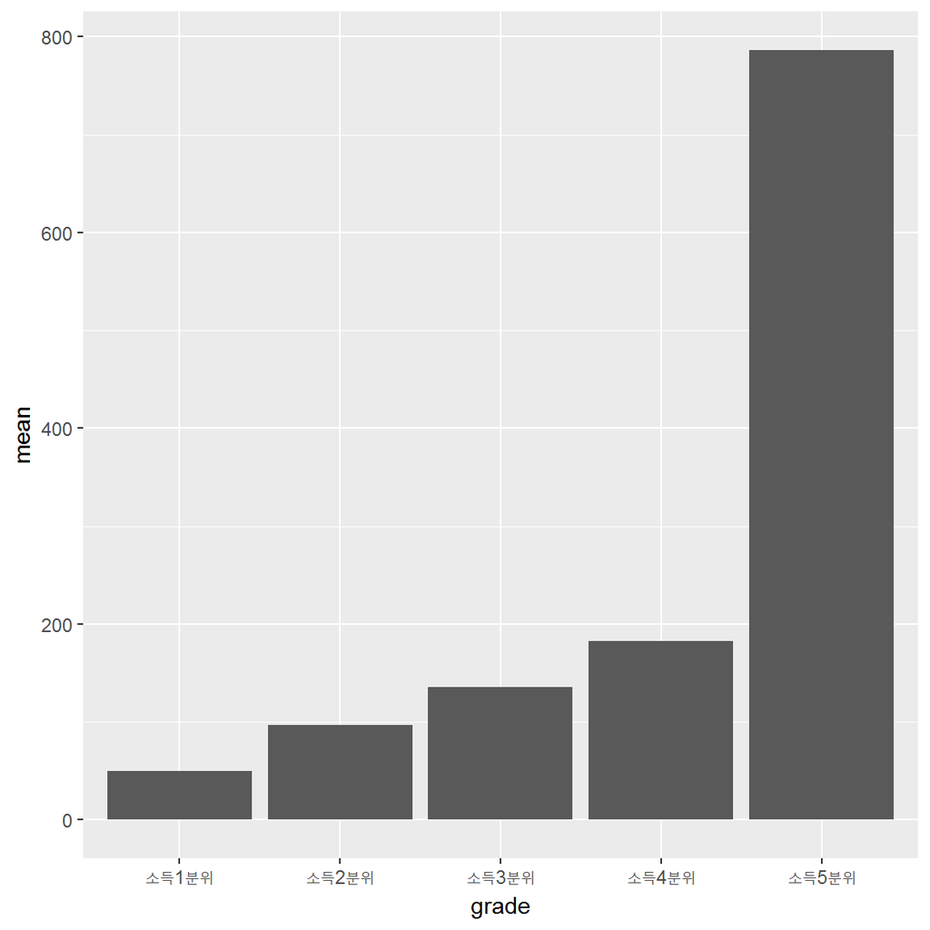

```r
dt8nn=merge(dt8, ig, by='V96',all=TRUE)
bar=dt8nn[,mean(V47),by=V96nn]
names(bar)=c("grade","mean")
ggplot(bar,aes(x=grade,y=mean))+geom_bar(stat="identity")
```